title: “pMT06-GR pDNA insert sequencing” author: “Max Trauernicht” date: “2021-05-14” output: prettydoc::html_pretty: theme: leonids highlight: github # toc: true # toc_float: true # code_folding: show # editor_options: # chunk_output_type: console — *knitr document van Steensel lab* # pMT06-GR pDNA insert sequencing # Introduction I sequenced the complete insert of the pDNA library of pMT06. I already extracted all sequences in front of the 3’ adapter from the sequences data and added counts to identical sequences by starcode. I now want to make an overview about how many pDNA insert sequences in the pDNA still match the designed inserts.

# Analysis

## How do the different samples correlate?

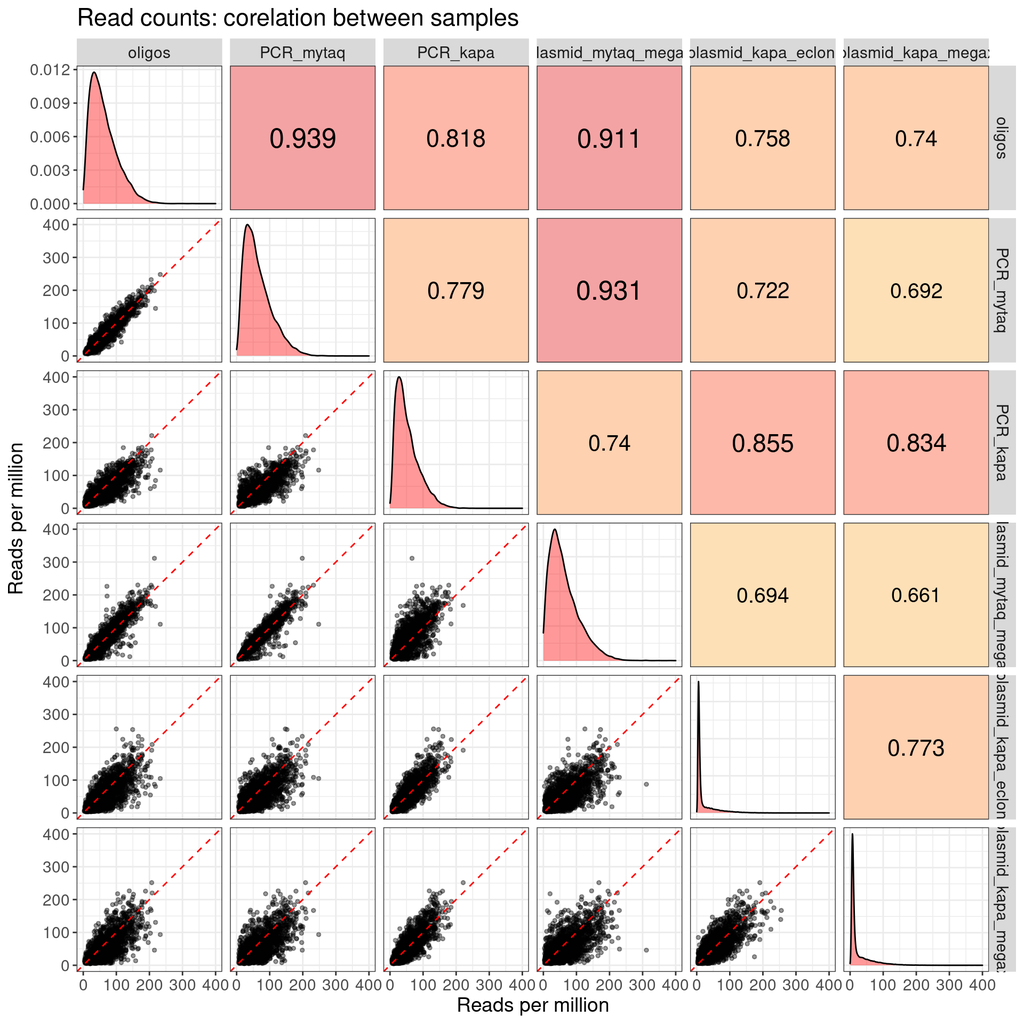

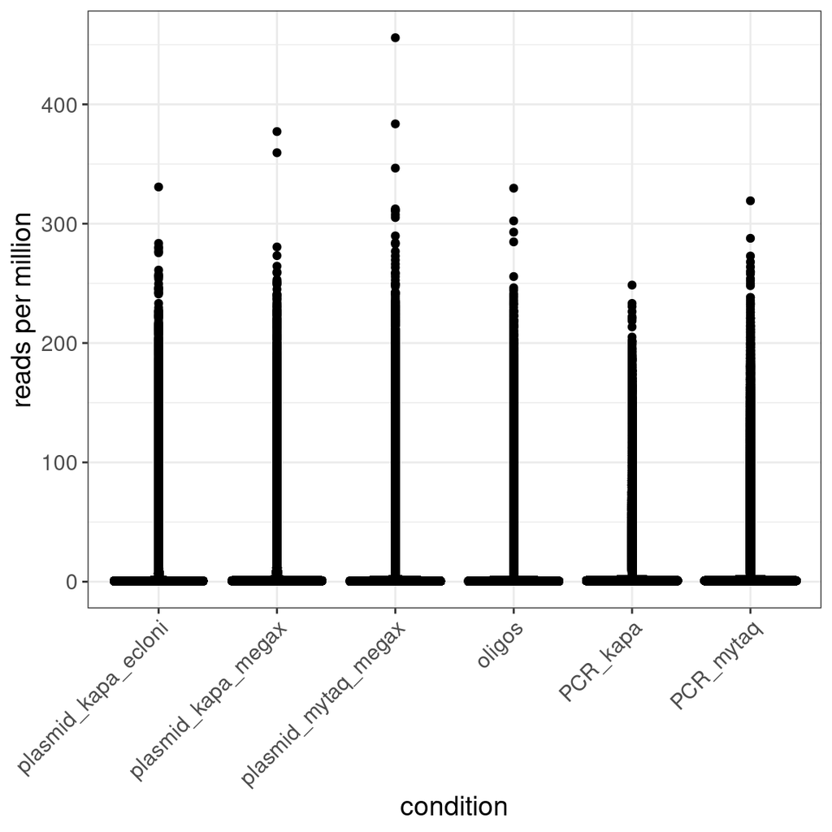

## Correlate to GC contenct

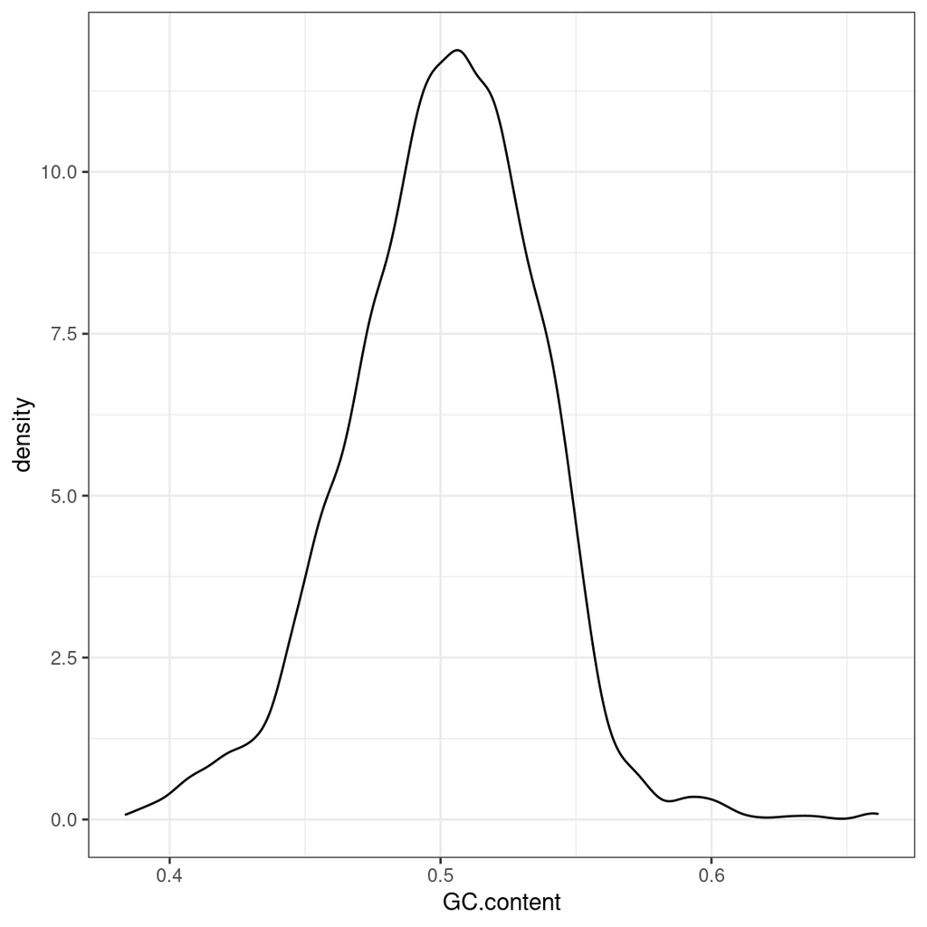

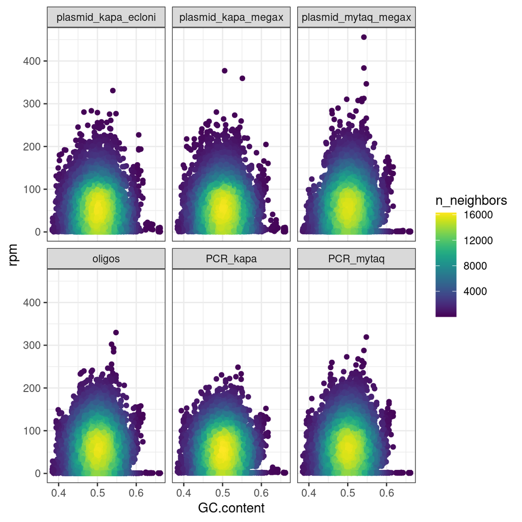

## Plot how many barcodes are found in pDNA data

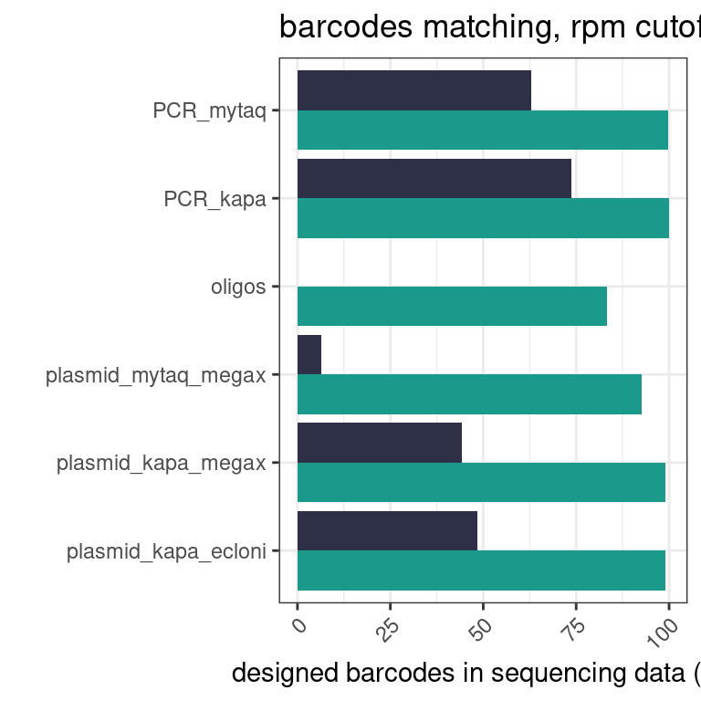

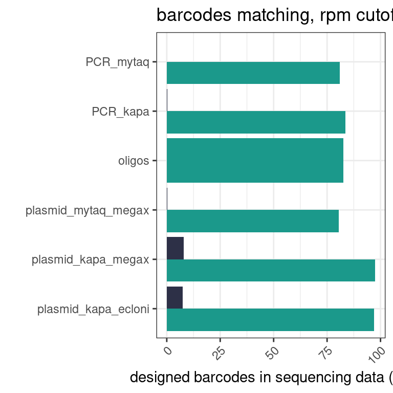

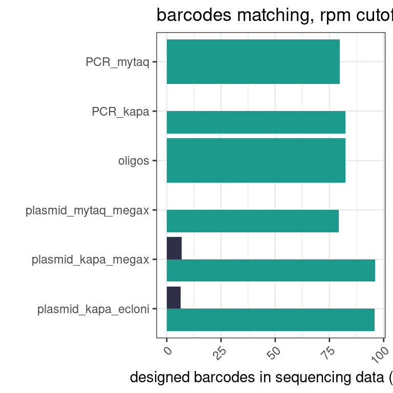

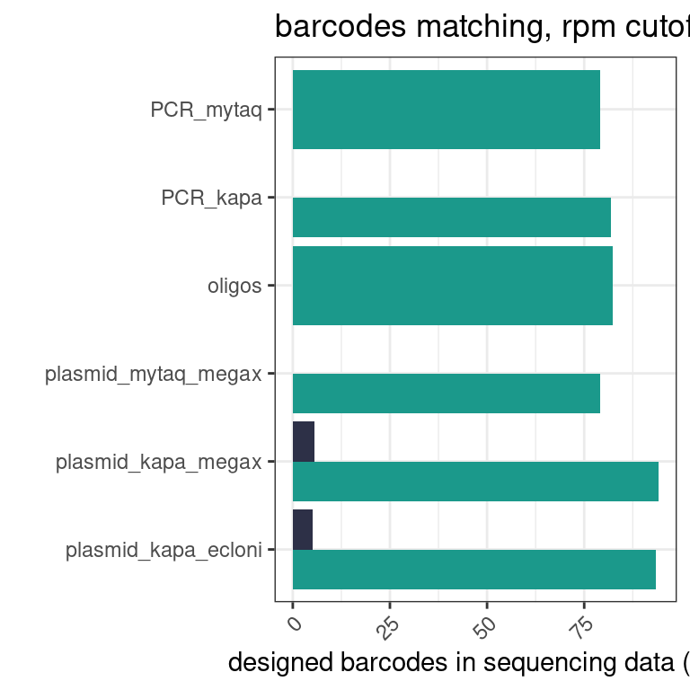

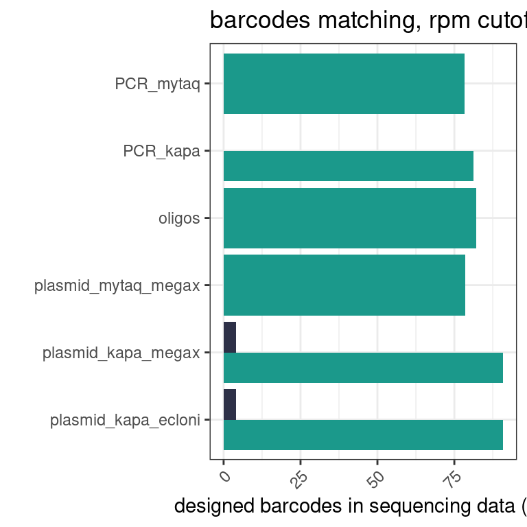

## Plot how many reads match to designed barcodes

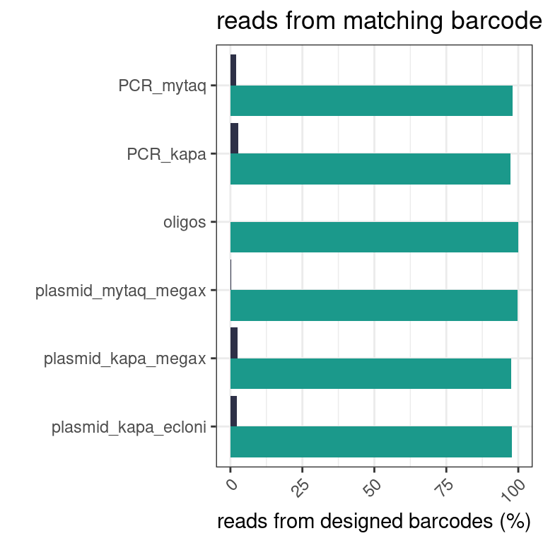

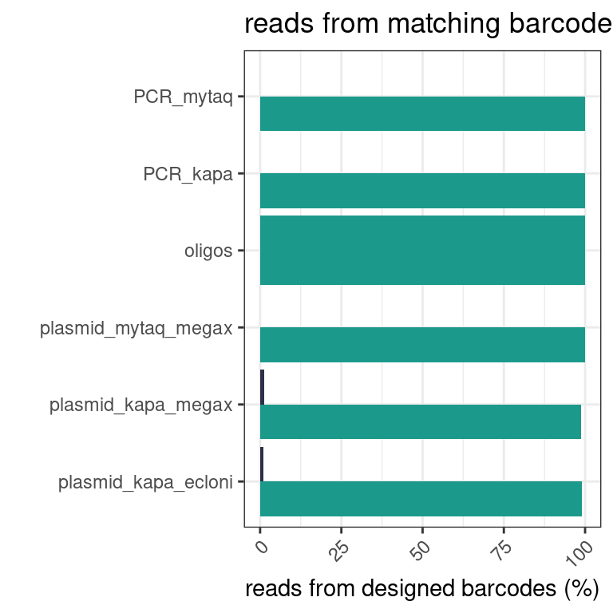

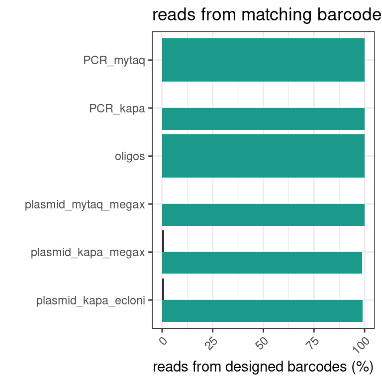

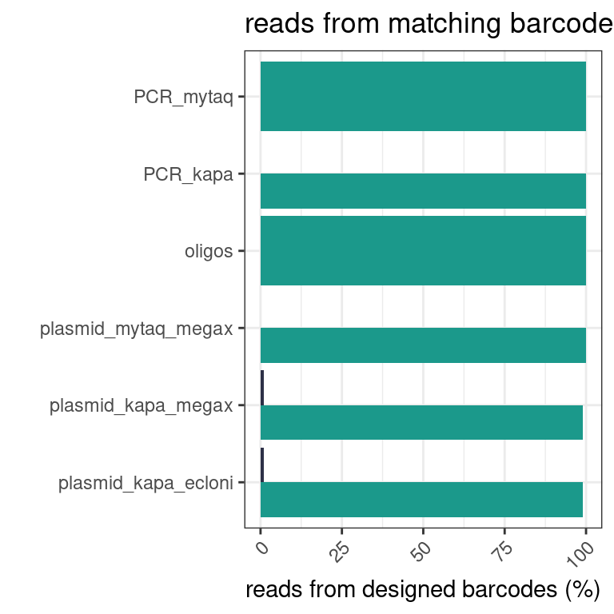

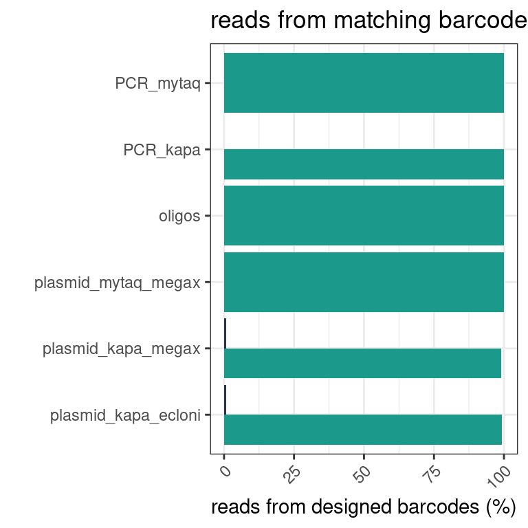

## How many raw complete sequences match with the design?

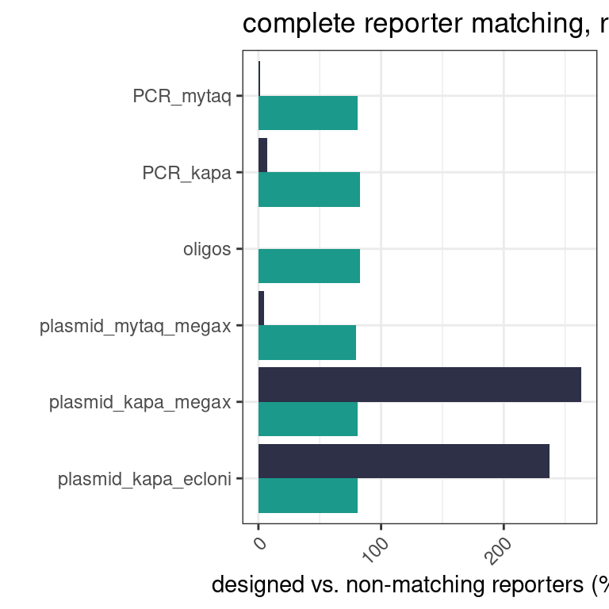

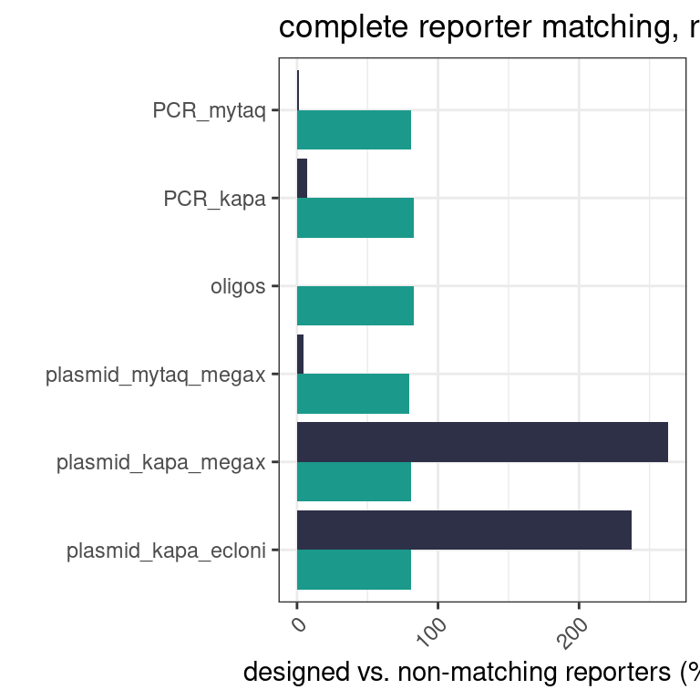

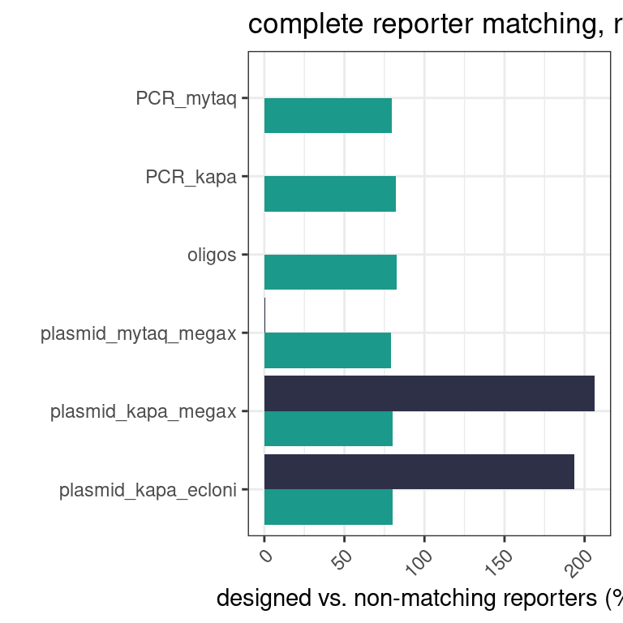

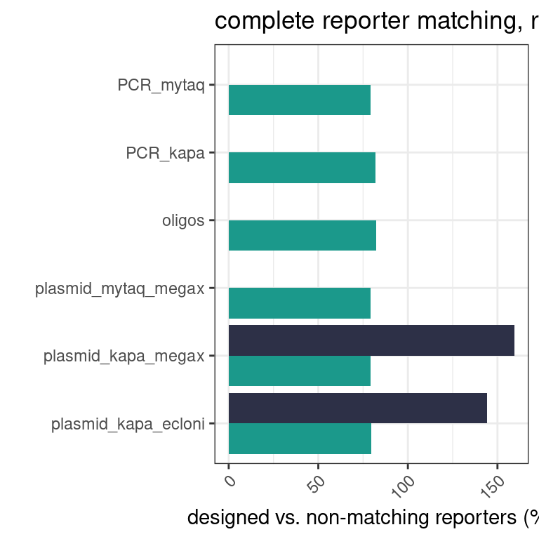

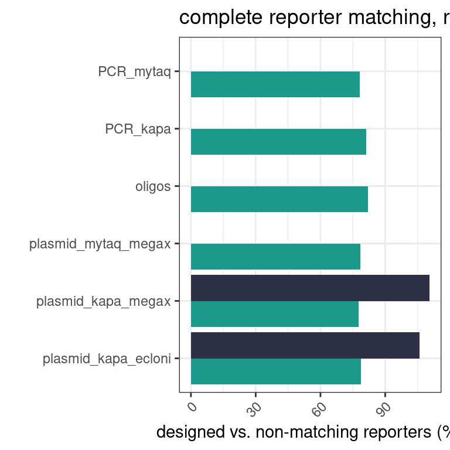

## Now we want to know the read distribution of matched/unmatched sequences

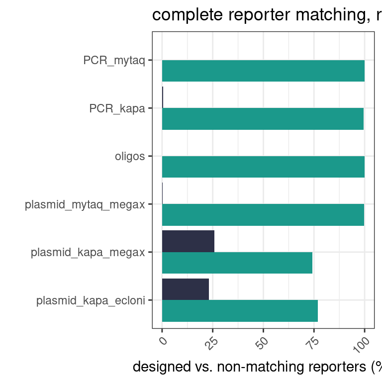

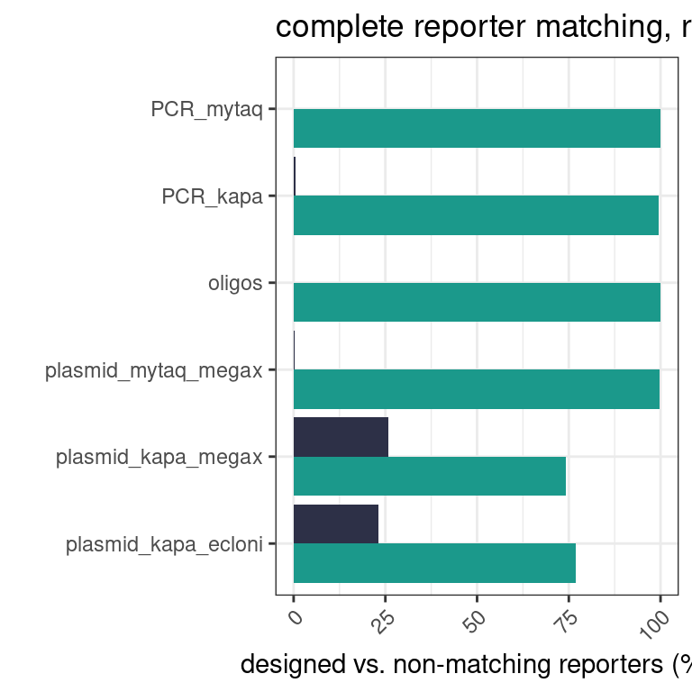

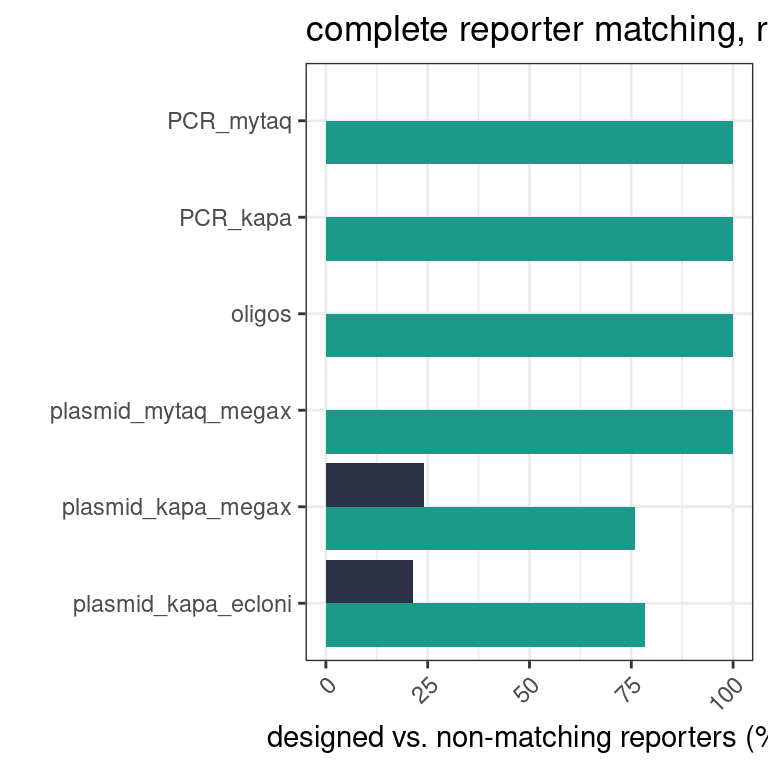

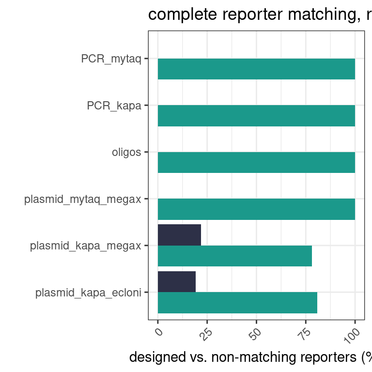

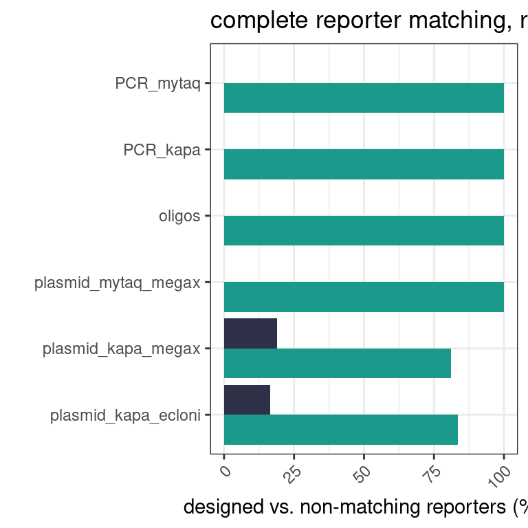

# Barcodes attached to wrong insert?

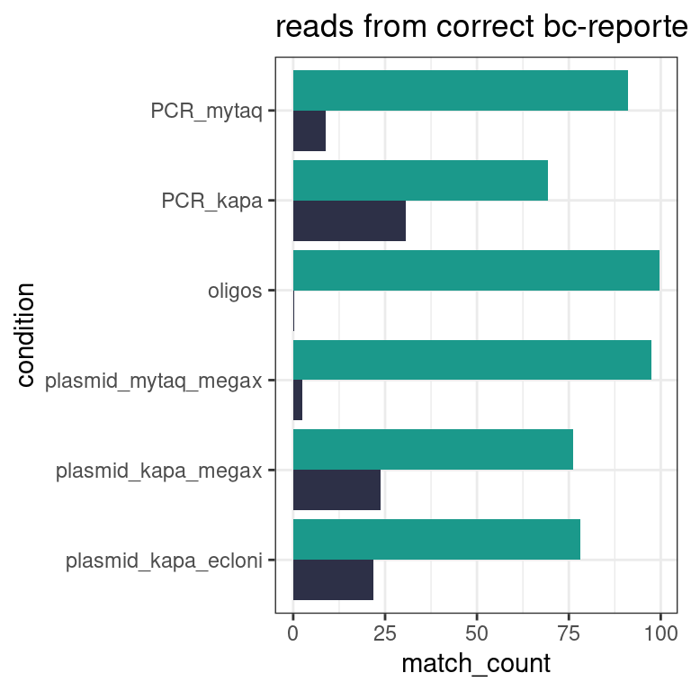

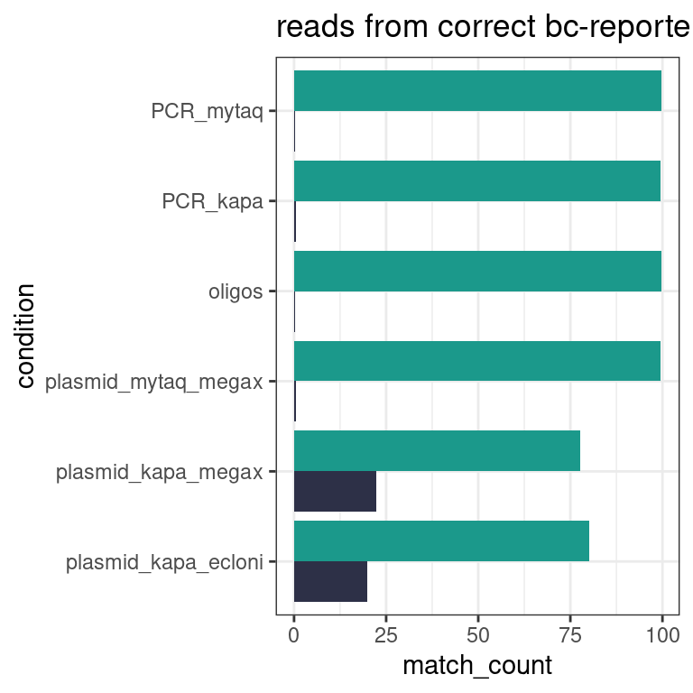

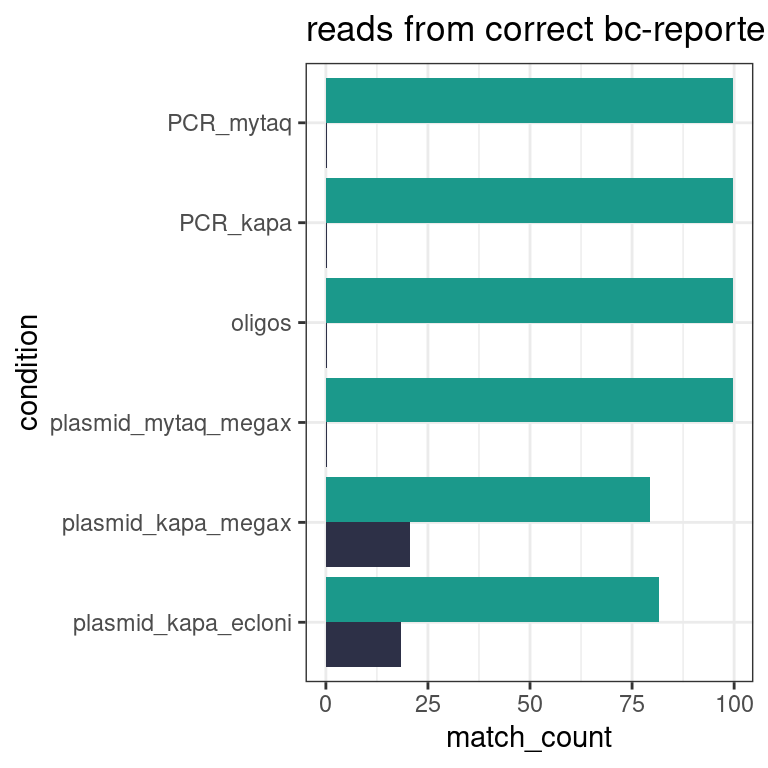

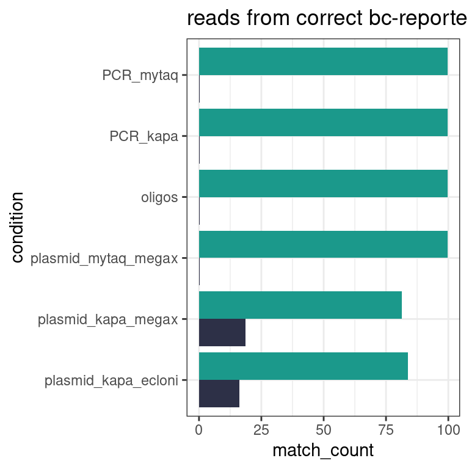

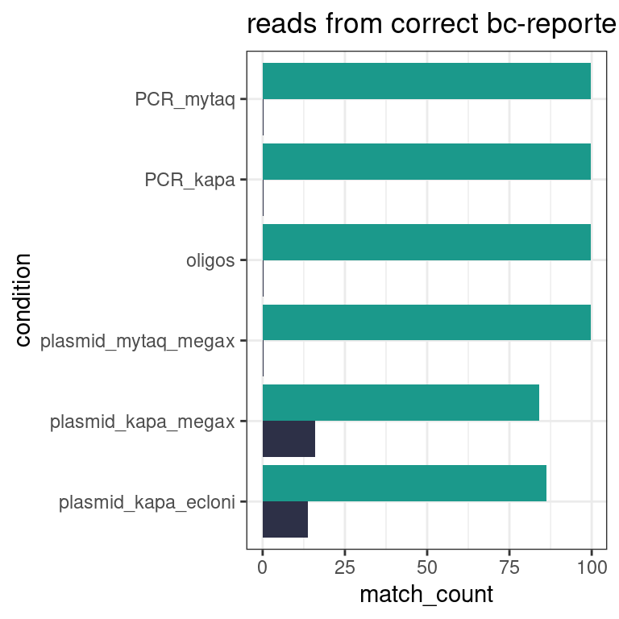

# Session Info

```r
paste("Run time: ",format(Sys.time()-StartTime))
```

```
## [1] "Run time:  5.541336 mins"
```

```r
getwd()
```

```
## [1] "/DATA/usr/t.filipovska/projects/library_TF_activity/analysis"
```

```r
date()
```

```
## [1] "Fri May 14 15:55:11 2021"
```